# Heatmap y PCA

Edith Serranía

2026-04-27

Cargar los paquetes para crear los heatmaps y PCA

```r
if (require("pacman"))
  install.packages("pacman")
```

```r
library("pacman")

p_load("pheatmap",
       "RColorBrewer",
       "ggplot",
       "dplyr",
       "vroom",
       "FactoMineR",
       "factoextra")
```

Llamar la base de datos

```r
Datos_PCR<- vroom("https://raw.githubusercontent.com/ManuelLaraMVZ/Heatmaps/refs/heads/main/Ejemplo%206x4.csv")
Datos_PCR
```

```
## # A tibble: 8 × 8
##   Gene  Condition Control_1 Control_2 Control_3 Tratamiento_1 Tratamiento_2
##   <chr> <chr>         <dbl>     <dbl>     <dbl>         <dbl>         <dbl>
## 1 Gen_1 Target         31.0      29.3      29.3          26.7          25.8
## 2 Gen_2 Target         30.1      29.1      29.5          28.8          26.3
## 3 Gen_3 Target         30.3      29.0      29.9          27.6          26.6
## 4 Gen_4 Target         25.4      26.5      25.5          32.1          28.7
## 5 Gen_5 Target         29.2      28.5      26.8          29.3          30.3
## 6 Gen_6 Target         27.9      27.9      27.8          30.6          29.9
## 7 Ref_1 Reference      26.0      24.9      25.5          24.6          25.6
## 8 Ref_2 Reference      25.9      24.1      25.0          24.9          25.1
## # ℹ 1 more variable: Tratamiento_3 <dbl>
```

Sacar genes de referencia para usarlos como comparativo

Sacar promedio de las referencias de los genes

```r
Ref_gen_prom<- Datos_PCR %>%
  filter(Condition == "Reference") %>%
  select(-1, -2) %>%
  summarise(across(everything(), mean, na.rm = TRUE ))
Ref_gen_prom
```

```
## # A tibble: 1 × 6
##   Control_1 Control_2 Control_3 Tratamiento_1 Tratamiento_2 Tratamiento_3
##       <dbl>     <dbl>     <dbl>         <dbl>         <dbl>         <dbl>
## 1      25.9      24.5      25.2          24.8          25.3          25.6
```

Primero se saca el promedio de los genes de referencia Después a cada gen analizado se le resta este promedio para el análisis

Sacar el valor de DCt de los datos

```r
Dct<- Datos_PCR %>%
  filter(Condition == "Target") %>%
  select(-2) %>%
  mutate(across(-1, ~ -(. -Ref_gen_prom[[cur_column()]][1]),
                .names = "Dct_{.col}")) %>%
  select(Gene, starts_with("Dct_"))

Dct
```

```
## # A tibble: 6 × 7
##   Gene  Dct_Control_1 Dct_Control_2 Dct_Control_3 Dct_Tratamiento_1
##   <chr>         <dbl>         <dbl>         <dbl>             <dbl>
## 1 Gen_1        -5.06          -4.81        -4.07              -1.93
## 2 Gen_2        -4.18          -4.57        -4.27              -4.06
## 3 Gen_3        -4.39          -4.51        -4.64              -2.78
## 4 Gen_4         0.543         -1.99        -0.295             -7.32
## 5 Gen_5        -3.25          -4.05        -1.52              -4.51
## 6 Gen_6        -1.95          -3.39        -2.58              -5.77
## # ℹ 2 more variables: Dct_Tratamiento_2 <dbl>, Dct_Tratamiento_3 <dbl>
```

Escalar los datos, sacar desviación estándar

```r
p_load("tibble")

miRNA_escalado<- Dct %>%
  column_to_rownames(var = "Gene") %>%
  scale(center = T,
        scale = T) %>%
  as.data.frame()

miRNA_escalado
```

```
##       Dct_Control_1 Dct_Control_2 Dct_Control_3 Dct_Tratamiento_1
## Gen_1   -0.97752739    -0.8723021    -0.6770509        1.25561926
## Gen_2   -0.54697365    -0.6467906    -0.7908920        0.17018773
## Gen_3   -0.65099203    -0.5891507    -1.0048539        0.82332900
## Gen_4    1.74092214     1.7982681     1.4987164       -1.49023458
## Gen_5   -0.09595052    -0.1547234     0.7918299       -0.05709921
## Gen_6    0.53052145     0.4646988     0.1822505       -0.70180220
##       Dct_Tratamiento_2 Dct_Tratamiento_3
## Gen_1         1.1138058         1.0531109
## Gen_2         0.8211332         1.0172933
## Gen_3         0.6773042         0.5261629
## Gen_4        -0.3957910        -1.3353215
## Gen_5        -1.1902479        -0.6502495
## Gen_6        -1.0262043        -0.6109962
```

Definir los colores del heatmap

```r
paleta_colores<- colorRampPalette(c("green", "black", "red")) (100)
```

Construir el heatmap, nos dice como se comporta el gen con respecto a su control y como se agrupan en jerarquías

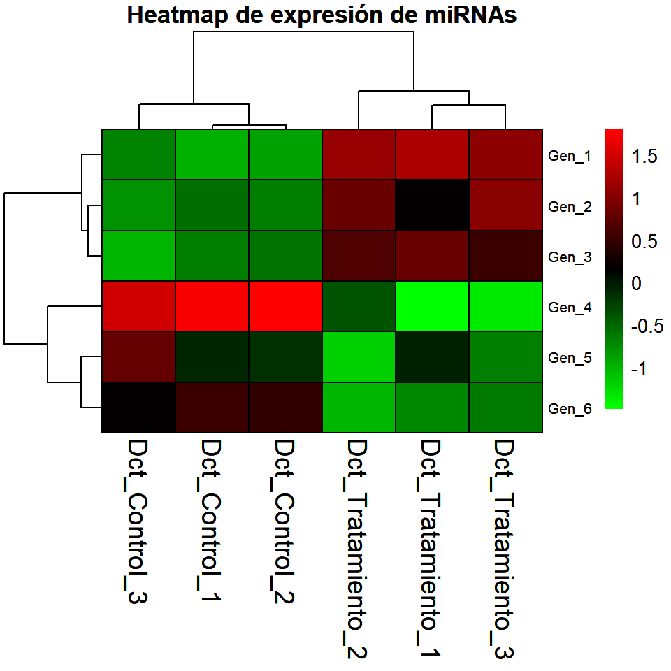

```r
Heatmap <- pheatmap(miRNA_escalado,
                    color = paleta_colores,
                    cluster_rows = T,
                    cluster_cols = T,
                    show_rownames = T,
                    show_colnames = T,
                    fontsize_row = 8,
                    fontsize_col = 14,
                    border_color = "black",
                    main = "Heatmap de expresión de miRNAs",
                    fontface_row = "bold")

Heatmap
```

Lo podemos hacer con más datos (copy paste el código hasta aquí y cambiar la base de datos)

```r
Datos_PCR2<- vroom("https://raw.githubusercontent.com/ManuelLaraMVZ/Heatmaps/refs/heads/main/miRNA_qPCR_Ct_Data_1550_miRNAs3.csv")
Datos_PCR2
```

```
## # A tibble: 1,552 × 10
##    Gene     Condition Control_1 Control_2 Control_3 Control_4 Treatment_1
##    <chr>    <chr>         <dbl>     <dbl>     <dbl>     <dbl>       <dbl>
##  1 miR-0001 Target         19.4      19.8      21.6      20.1        30.1
##  2 miR-0002 Target         29.3      29.6      31.2      30.4        20.4
##  3 miR-0003 Target         20.5      18.0      20.7      19.5        28.9
##  4 miR-0004 Target         29.4      28.3      30.8      30.2        18.9
##  5 miR-0005 Target         20.9      20.9      20.8      20.7        30.6
##  6 miR-0006 Target         29.3      29.8      28.7      32.2        21.2
##  7 miR-0007 Target         20.8      19.9      20.3      20.0        30.0
##  8 miR-0008 Target         28.5      30.6      30.1      30.2        20.4
##  9 miR-0009 Target         18.9      20.3      20.4      20.1        30.9
## 10 miR-0010 Target         31.0      29.3      29.3      31.0        19.7
## # ℹ 1,542 more rows
## # ℹ 3 more variables: Treatment_2 <dbl>, Treatment_3 <dbl>, Treatment_4 <dbl>
```

```r
Ref_gen_prom2<- Datos_PCR2 %>%
  filter(Condition == "Reference") %>%
  select(-1, -2) %>%
  summarise(across(everything(), mean, na.rm = TRUE ))

Ref_gen_prom2
```

```
## # A tibble: 1 × 8
##   Control_1 Control_2 Control_3 Control_4 Treatment_1 Treatment_2 Treatment_3
##       <dbl>     <dbl>     <dbl>     <dbl>       <dbl>       <dbl>       <dbl>
## 1      24.8      24.9      24.5      25.1        25.1        25.2        24.7
## # ℹ 1 more variable: Treatment_4 <dbl>
```

```r
Dct2<- Datos_PCR2 %>%
  filter(Condition == "Target") %>%
  select(-2) %>%
  mutate(across(-1, ~ -(. -Ref_gen_prom2[[cur_column()]][1]),
                .names = "Dct_{.col}")) %>%
  select(Gene, starts_with("Dct_"))

Dct2
```

```
## # A tibble: 1,550 × 9
##    Gene  Dct_Control_1 Dct_Control_2 Dct_Control_3 Dct_Control_4 Dct_Treatment_1
##    <chr>         <dbl>         <dbl>         <dbl>         <dbl>           <dbl>
##  1 miR-…          5.34          5.13          2.98          5.00           -5.03
##  2 miR-…         -4.53         -4.65         -6.69         -5.29            4.69
##  3 miR-…          4.29          6.87          3.83          5.54           -3.84
##  4 miR-…         -4.59         -3.41         -6.30         -5.09            6.23
##  5 miR-…          3.89          4.02          3.71          4.38           -5.46
##  6 miR-…         -4.52         -4.89         -4.20         -7.10            3.89
##  7 miR-…          4.00          4.98          4.28          5.10           -4.86
##  8 miR-…         -3.67         -5.68         -5.59         -5.15            4.72
##  9 miR-…          5.85          4.60          4.09          5.01           -5.83
## 10 miR-…         -6.22         -4.39         -4.78         -5.96            5.38
## # ℹ 1,540 more rows
## # ℹ 3 more variables: Dct_Treatment_2 <dbl>, Dct_Treatment_3 <dbl>,
## #   Dct_Treatment_4 <dbl>
```

```r
miRNA_escalado2<- Dct2 %>%
  column_to_rownames(var = "Gene") %>%
  scale(center = T,
        scale = T) %>%
  as.data.frame()

miRNA_escalado2
```

[output not shown]

[output cut: 3047 more lines]

[output not shown]

Quitamos el nombre de los genes poniendo false

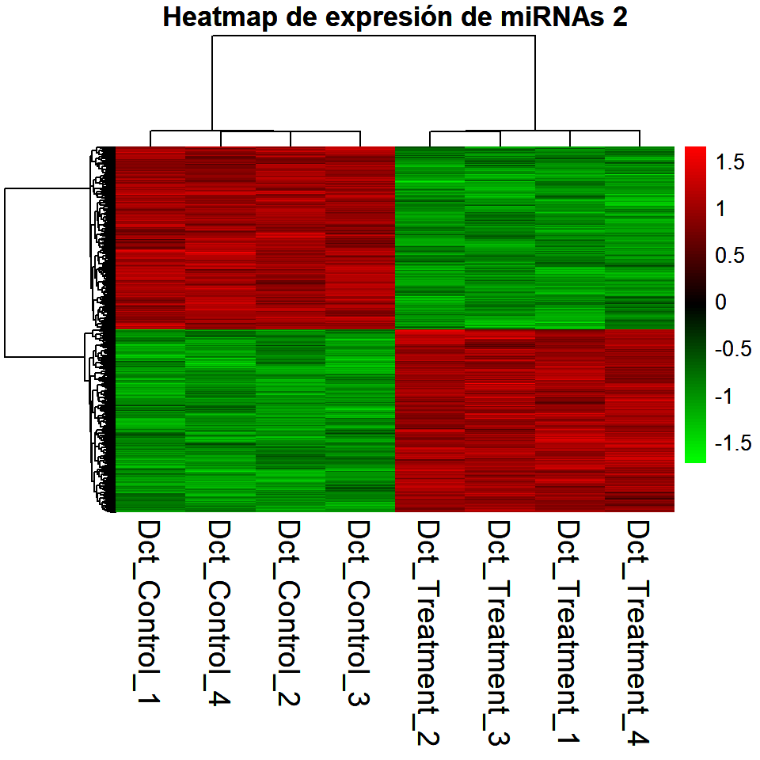

```r
Heatmap <- pheatmap(miRNA_escalado2,
                    color = paleta_colores,
                    cluster_rows = T,
                    cluster_cols = T,
                    show_rownames = F,
                    show_colnames = T,
                    fontsize_row = 8,
                    fontsize_col = 14,
                    border_color = "black",
                    main = "Heatmap de expresión de miRNAs 2",
                    fontface_row = "bold")

Heatmap
```

Análisis de PCA

Primero calcular el PCA

```r
PCA_resultados<- prcomp(t(miRNA_escalado2),
                        center = TRUE,
                        scale. = T)

summary(PCA_resultados)
```

```
## Importance of components:
##                            PC1     PC2     PC3     PC4     PC5     PC6     PC7
## Standard deviation     38.7928 2.87800 2.79848 2.76461 2.72127 2.65848 2.62467
## Proportion of Variance  0.9709 0.00534 0.00505 0.00493 0.00478 0.00456 0.00444
## Cumulative Proportion   0.9709 0.97623 0.98129 0.98622 0.99100 0.99556 1.00000
##                              PC8
## Standard deviation     2.239e-14
## Proportion of Variance 0.000e+00
## Cumulative Proportion  1.000e+00
```

Screenplot: Varianza explicada por componente

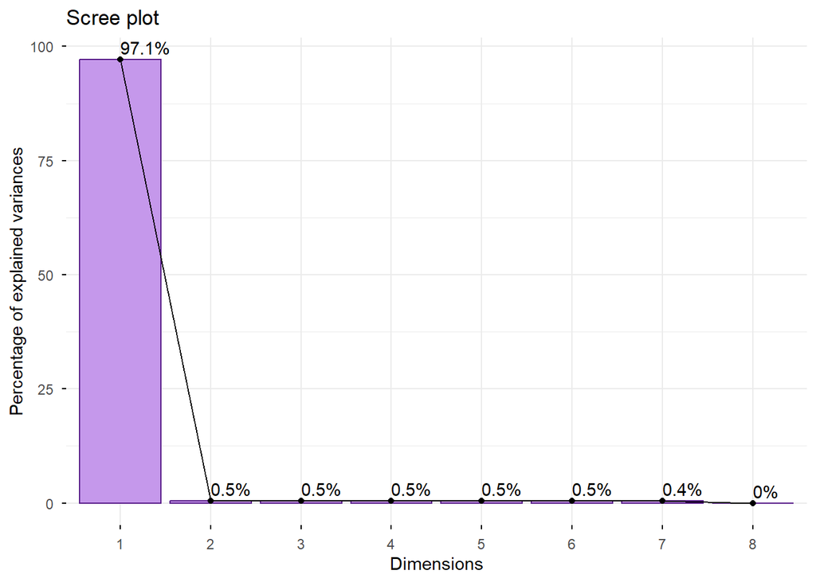

```r
fviz_eig(PCA_resultados,
         addlabels = T,
         barfill = "#C598EB",
         barcolor = "#571B88")
```

Esta gráfica nos dice que las varianzas se explican sobretodo en el PCA1

Gráfica de PCA (biplot)

```r
PCA_df<- as.data.frame(PCA_resultados$x)
PCA_df$Sample<- rownames(PCA_df)
```

Graficarlo

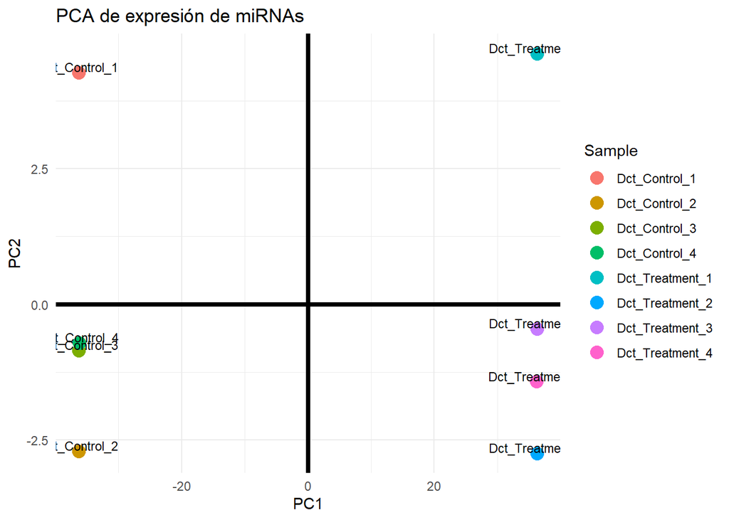

```r
PCA_plot <- ggplot(PCA_df,
                   aes(x = PC1,
                       y = PC2,
                       label = Sample)) +
  geom_point(size = 4, aes(color = Sample)) +
  geom_text(vjust = -0.1, size = 3) +
  geom_hline(yintercept = 0, linetype = "solid", color = "black", linewidth = 1.5) +
  geom_vline(xintercept = 0, linetype = "solid", color = "black", linewidth = 1.5) +
  labs(title = "PCA de expresión de miRNAs",
       x = "PC1",
       y = "PC2") +
  theme_minimal()

PCA_plot
```

Analizar el comportamiento de los genes

```r
PCA_resultados_genes<- prcomp(miRNA_escalado2,
                              center = T,
                              scale. = T)

summary(PCA_resultados_genes)
```

```
## Importance of components:
##                           PC1     PC2     PC3     PC4     PC5     PC6     PC7
## Standard deviation     2.7806 0.20838 0.20321 0.19693 0.19657 0.19219 0.18799
## Proportion of Variance 0.9665 0.00543 0.00516 0.00485 0.00483 0.00462 0.00442
## Cumulative Proportion  0.9665 0.97188 0.97704 0.98189 0.98672 0.99134 0.99575
##                            PC8
## Standard deviation     0.18430
## Proportion of Variance 0.00425
## Cumulative Proportion  1.00000
```

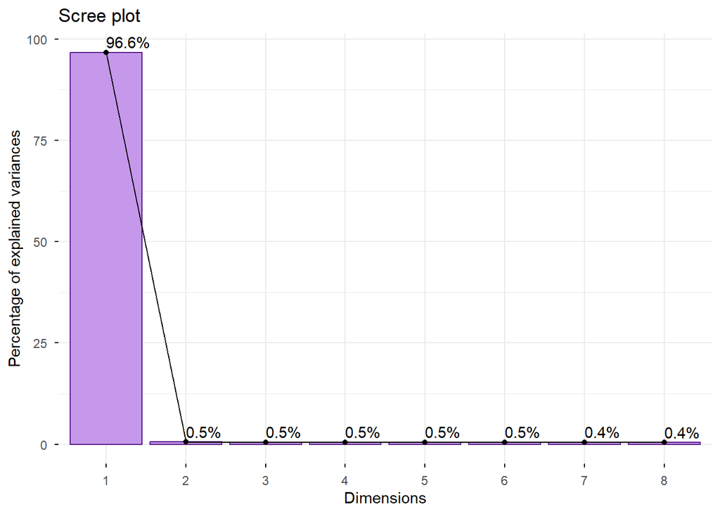

```r
fviz_eig(PCA_resultados_genes, addlabels = T, barfill = "#C598EB",
         barcolor = "#571B88")
```

```r
PCA_df_genes<- as.data.frame(PCA_resultados_genes$x)
PCA_df_genes$Gene<- row.names(PCA_df_genes)
```

Gráfica

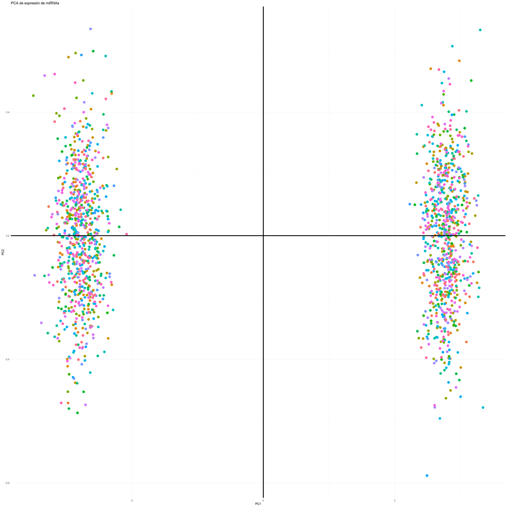

```r
PCA_plot_genes<- ggplot(PCA_df_genes,
                        aes(x = PC1,
                            y = PC2,
                            label = Gene))+
  geom_point(size=4, aes(color = Gene), show.legend = F)+
  #geom_text(vjust = -0.05, size = 3)+
  geom_hline(yintercept = 0, linetype = "solid", color = "black", linewidth = 1.5) +
  geom_vline(xintercept = 0, linetype = "solid", color = "black", linewidth = 1.5) +
  labs(title = "PCA de expresión de miRNAs",
       x = "PC1",
       y = "PC2") +
  theme_minimal()

PCA_plot_genes
```

Podemos cambiar la base de datos y copiar el mismo código, esto permite ver cuales genes se parecen entre sí